# Predict Failure

## 1.3 Using the LOG transformed dataset

```r
log.data_15 <- cbind.data.frame("LeadToFailure"=data_15$LeadToFailure, log(data_15[,2:10]+1))
log.train_ <- log.data_15[1:4000,]
log.test_ <- log.data_15[4001:15000,]
```

```r
n <- names(log.train_)
# the equation was finalized after few iterations
f <- as.formula(paste("LeadToFailure ~", paste(n[!n %in% c("LeadToFailure","WatGCon","WatMCon","CmpACon","WatWGen")], collapse = " + ")))
logR.mdl <- glm(f,data = log.train_,family = binomial(link = "logit"))
summary(logR.mdl)
```

```
Call:
glm(formula = f, family = binomial(link = "logit"), data = log.train_)

Deviance Residuals:
       Min          1Q      Median          3Q         Max
-1.3666502  -0.1531848  -0.1360136  -0.1178892   3.3645627

Coefficients:
                  Estimate   Std. Error  z value        Pr(>|z|)
(Intercept)   -18.01302752   5.87078781 -3.06825       0.0021532 **
Production     -6.67506278   1.15439833 -5.78229 0.0000000073692 ***
Hay_out_waste   0.16914063   0.05871763  2.88058       0.0039695 **
EleCon          2.48466458   0.99549702  2.49590       0.0125637 *
NatGCon        -0.40548154   0.19997924 -2.02762       0.0425992 *
SteCon          0.41467726   0.18389192  2.25501       0.0241330 *
---
Signif. codes:  0 â€˜***â€™ 0.001 â€˜**â€™ 0.01 â€˜*â€™ 0.05 â€˜.â€™ 0.1 â€˜ â€™ 1

(Dispersion parameter for binomial family taken to be 1)

    Null deviance: 580.77907  on 3999  degrees of freedom
Residual deviance: 513.13746  on 3994  degrees of freedom
AIC: 525.13746

Number of Fisher Scoring iterations: 7
```

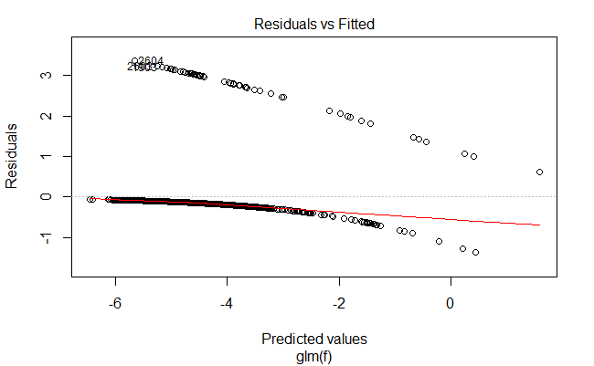

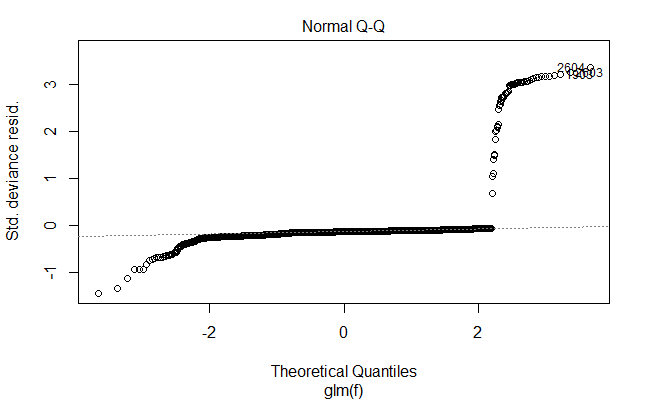

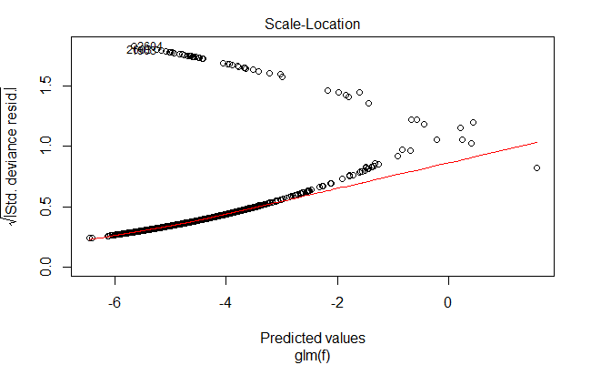

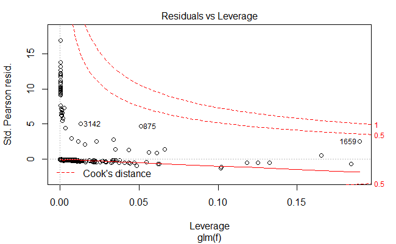

```r
plot(logR.mdl)
```

```r
p<- predict(logR.mdl,newdata = log.test_,type = "response")
#pr <- prediction(p,log.test_$LeadToFailure)
#prf <- performance(pr, measure = "tpr", x.measure = "fpr")
#plot(prf)
#auc <- performance(pr, measure = "auc")
#auc <- auc@y.values[[1]]
#auc
```

**Notes on Log Transformed dataset:** It has been observed consistently throughout the LOG transformed data has performed better. However, the dataset still contains outliers that needs to be dealt with.

**PLEASE NOTE THAT THE PREDICTION FUNCTION STARTED FAILING FEW MINUTES BEFORE SUBMISSION :-(** 75% was observed earlier.

**Notes for Future:** Like the slicing of data based on the Production variable at different MT values, there shall be multiple *SEASONAL* slices applied on the dataset, like summer, winter,etc., or even monthly.

# 2 Neural Network

A similar approach, i.e., trying to predict the logistic outcome of failures on the same dataset, lead to few more insights and conclusions.

## 2.1 Using the min-max transformation dataset

```r
n <- names(train_)
f <- as.formula(paste("LeadToFailure ~", paste(n[!n %in% "LeadToFailure"], collapse = " + ")))
nn <- neuralnet(f, data = train_, hidden = c(7,5,3,1),linear.output = FALSE,lifesign = "minimal", threshold = 0.1)
```

```
hidden: 7, 5, 3, 1    thresh: 0.1    rep: 1/1    steps:      27 error: 27.12223 time: 0.43 secs
```

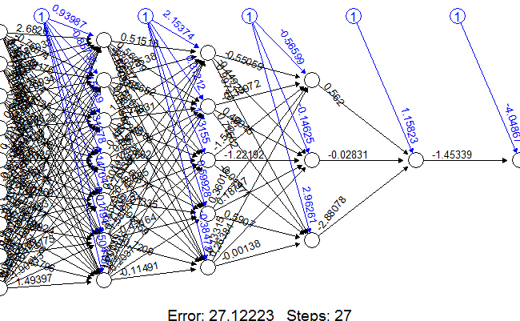

```r
plot(nn)
```

```r
# predict using the test set
# leaving the y, passing the rest of the variables
pr.nn <- compute(nn,test_[,2:10])
plot(test_$LeadToFailure,pr.nn$net.result,col='blue',main='Real vs predicted NN',pch=18,cex=0.7)
abline(0,1,lwd=2)
```

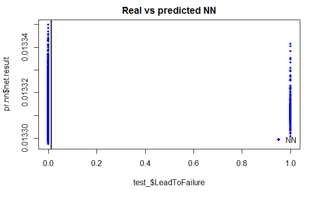

```r
legend('bottomright',legend='NN',pch=18,col='blue', bty='n')
```

__Notes:__ High error values (~27) and the predicted values are always close 0. The model did not predict the FAILURE not even once.

## 2.2 Using the LOG transformed dataset

```r
log.data_15 <- cbind.data.frame("LeadToFailure"=data_15$LeadToFailure, log(data_15[,2:10]+1))
# An observation was made that when the dataset size was brought down to 2000 , from 4000 the error came down drastically.
log.train_ <- log.data_15[1:2000,]
log.test_ <- log.data_15[4001:6000,]
n <- names(log.train_)
f <- as.formula(paste("LeadToFailure ~", paste(n[!n %in% c("LeadToFailure","WatGCon","WatMCon","CmpACon","WatWGen")], collapse = " + ")))
nn <- neuralnet(f, data = log.train_, hidden = 4,linear.output = FALSE,lifesign = "minimal", threshold = 0.1)
```

```
hidden: 4    thresh: 0.1    rep: 1/1    steps:      10  error: 12.38319 time: 0.82 secs
```

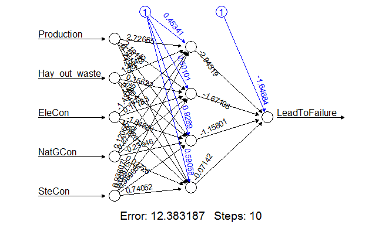

```r
plot(nn)
```

__Notes:__ The error came down.

Predicting the failure using the Neural net

```r
#dropping unwanted columns from test data
log2 <- log.test_[,-4]
log2 <- log2[1:6]
prL.nn <- compute(nn,log2[,2:6])
MSE.nn <- sum((log2$LeadToFailure - prL.nn$net.result)^2)/nrow(log2)
print(paste("Mean Square Error in NN = ",MSE.nn))
```

```
[1] "Mean Square Error in NN =  0.01386226300919"
```

```r
# plot the results
plot(log2$LeadToFailure,prL.nn$net.result,col='blue',main='Real vs predicted NN',pch=18,cex=0.7)
abline(0,1,lwd=2)
```

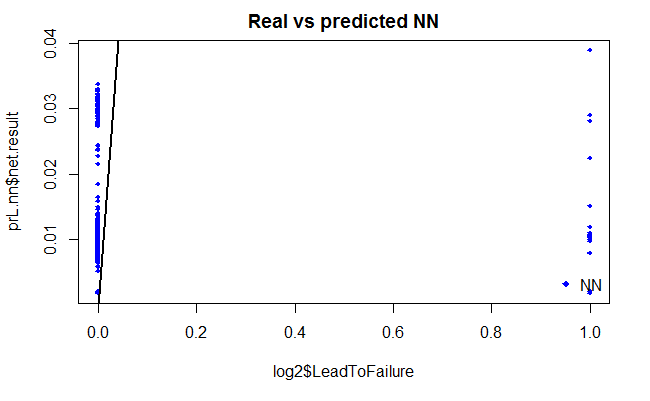

```r
legend('bottomright',legend='NN',pch=18,col='blue', bty='n')
```

**Observations:** LOG transformed data (with reduced size) behave very similar or close to the Min-Max transformed dataset. But the predicted values have improved very little but still always close to ZERO, meaning that Neural network did not predict FAILURE (TRUE) condition at all.

## 2.3 Conclusions

Overall, the models used here were not satisfactory (even if it has ROC values of 75%) in my opinion. And the seasonality & trend influences are very evident throughout. Moreover, using *DUMMY* variable that leads to a failure is an idea, not a robust method to predict failures in a large pool of dataset like this. A very deep analysis is necessary to realign the approach in predicting the failure. This could be possible by adding more attributes given at machine level with more sophisticated application of methods.